# The Leading Causes of Death In The United States

## Part 2: Data Management

I want to look at the first cause name column which is just a more specific/professional name of the type of cause you would hear from a doctor for example, while the second cause name column is what you would most commonly refer the cause to in the simplest terms. The age-adjusted death rate column is just a way to control the differences in the population age distribtuions. So for my purposes I can get rid of the first cause name column because it is just an extension for the second cause name column, as well as the age-adjusted death rate column because I will not be focusing on that in my research. I also want to only look at the data for just the United States throughout the years, so I will also drop all the rows that are not the United States which include the 50 individual states and the District of Columbia. Similarly, I will drop the unnecessary columns and rows for the Maryland table as well as the Missouri table.

```python
#First start by dropping the 2 columns for the United States only table
data_US = data.drop(["113 Cause Name"], axis=1)
data_US = data_US.drop(["Age-adjusted Death Rate"], axis=1)

#Dropping all non "United States" rows so we can have a table of just the United States
for i, row in data_US.iterrows():
    if row["State"] != "United States":
        data_US.drop(i, inplace=True)
#Unfortunately the row for 2007 is out of order so we need to reorder the dataframe
data_US = data_US.sort_values('Year')
#Want to reverse data so it can start from 1999 and go up to 2017
data_US = data_US.loc[::-1]
data_US
```

|  | Year | Cause Name | State | Deaths |
| --- | --- | --- | --- | --- |
| 0 | 2017 | Unintentional injuries | United States | 169936 |
| 260 | 2017 | Diabetes | United States | 83564 |
| 521 | 2017 | Kidney disease | United States | 50633 |
| 469 | 2017 | Cancer | United States | 599108 |
| 416 | 2017 | Suicide | United States | 47173 |
| ... | ... | ... | ... | ... |
| 10496 | 1999 | Stroke | United States | 167366 |
| 10444 | 1999 | Alzheimer's disease | United States | 44536 |
| 10392 | 1999 | All causes | United States | 2391399 |
| 10341 | 1999 | Unintentional injuries | United States | 97860 |
| 10860 | 1999 | Kidney disease | United States | 35525 |

209 rows × 4 columns

```python
#First start by dropping the 2 columns for the Maryland only table
data_MD = data.drop(["113 Cause Name"], axis=1)
data_MD = data_MD.drop(["Age-adjusted Death Rate"], axis=1)

#Dropping all non "United States" rows so we can have a table of just Maryland
for i, row in data_MD.iterrows():
    if row["State"] != "Maryland":
        data_MD.drop(i, inplace=True)
#Unfortunately the row for 2007 is out of order so we need to reorder the dataframe
data_MD = data_MD.sort_values('Year')
#Want to reverse data so it can start from 1999 and go up to 2017
data_MD = data_MD.loc[::-1]
data_MD
```

|  | Year | Cause Name | State | Deaths |
| --- | --- | --- | --- | --- |
| 21 | 2017 | Unintentional injuries | Maryland | 2408 |
| 281 | 2017 | Diabetes | Maryland | 1439 |
| 542 | 2017 | Kidney disease | Maryland | 830 |
| 490 | 2017 | Cancer | Maryland | 10796 |
| 437 | 2017 | Suicide | Maryland | 630 |
| ... | ... | ... | ... | ... |
| 10472 | 1999 | Stroke | Maryland | 2892 |
| 10420 | 1999 | Alzheimer's disease | Maryland | 681 |
| 10369 | 1999 | All causes | Maryland | 43089 |
| 10316 | 1999 | Unintentional injuries | Maryland | 1296 |
| 10836 | 1999 | Kidney disease | Maryland | 563 |

209 rows × 4 columns

```python
#First start by dropping the 2 columns for the Missouri only table
data_MO = data.drop(["113 Cause Name"], axis=1)
data_MO = data_MO.drop(["Age-adjusted Death Rate"], axis=1)

#Dropping all non "United States" rows so we can have a table of just Missouri
for i, row in data_MO.iterrows():
    if row["State"] != "Missouri":
        data_MO.drop(i, inplace=True)
#Unfortunately the row for 2007 is out of order so we need to reorder the dataframe
data_MO = data_MO.sort_values('Year')
#Want to reverse data so it can start from 1999 and go up to 2017
data_MO = data_MO.loc[::-1]
data_MO
```

|  | Year | Cause Name | State | Deaths |
| --- | --- | --- | --- | --- |
| 26 | 2017 | Unintentional injuries | Missouri | 3776 |
| 286 | 2017 | Diabetes | Missouri | 1605 |
| 547 | 2017 | Kidney disease | Missouri | 1515 |
| 495 | 2017 | Cancer | Missouri | 12971 |
| 442 | 2017 | Suicide | Missouri | 1151 |
| ... | ... | ... | ... | ... |
| 10477 | 1999 | Stroke | Missouri | 3950 |
| 10425 | 1999 | Alzheimer's disease | Missouri | 914 |
| 10374 | 1999 | All causes | Missouri | 55931 |
| 10322 | 1999 | Unintentional injuries | Missouri | 2465 |
| 10841 | 1999 | Kidney disease | Missouri | 907 |

209 rows × 4 columns

## Part 3: Exploratory Data Analysis

For this part, I want to first get a better understanding for the 3 datasets. I will achieve this by graphing the total deaths in the United States, Maryland, and Missouri. I want to see if there are any similarities or differences between the 3 graphs in terms of their shape. I am expecting them to all be the similar shape but with the United States graph clearly having a much bigger death count than the other 2 single states. After this, I will analyze the graphs and look for any points of interest that may be worth the time to further examine.

```
       Year  Cause Name          State   Deaths
10392  1999  All causes  United States  2391399
9820   2000  All causes  United States  2403351
9248   2001  All causes  United States  2416425
8676   2002  All causes  United States  2443387
8104   2003  All causes  United States  2448288
7532   2004  All causes  United States  2397615
6960   2005  All causes  United States  2448017
6388   2006  All causes  United States  2426264
4531   2007  All causes  United States  2423712
5267   2008  All causes  United States  2471984
4689   2009  All causes  United States  2437163
4105   2010  All causes  United States  2468435
3533   2011  All causes  United States  2515458
2960   2012  All causes  United States  2543279
2386   2013  All causes  United States  2596993
1814   2014  All causes  United States  2626418
1241   2015  All causes  United States  2712630
669    2016  All causes  United States  2744248
52     2017  All causes  United States  2813503
```

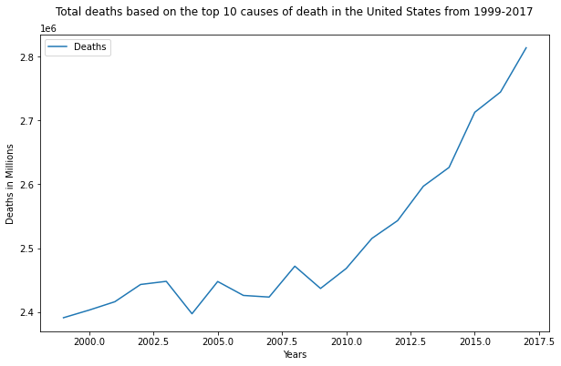

```python
#Creating a dataframe of the total causes of death from 1999-2017 in the United States
all_causes_US = data_US.copy()
for i, row in all_causes_US.iterrows():
    if row["Cause Name"] != "All causes":
        all_causes_US.drop(i, inplace=True)
#Unfortunately the row for 2007 is out of order so we need to reorder the dataframe
all_causes_US = all_causes_US.sort_values('Year')
print(all_causes_US)
all_causes_US.plot(x="Year", y="Deaths",figsize=(10,6))
plt.xlabel("Years")
plt.ylabel("Deaths in Millions")
plt.title("Total deaths based on the top 10 causes of death in the United States from 1999-2017\n")
plt.show()
```

```
       Year  Cause Name     State  Deaths
10369  1999  All causes  Maryland   43089
9798   2000  All causes  Maryland   43753
9225   2001  All causes  Maryland   43839
8653   2002  All causes  Maryland   43970
8080   2003  All causes  Maryland   44499
7509   2004  All causes  Maryland   43232
6936   2005  All causes  Maryland   43892
6364   2006  All causes  Maryland   43582
5816   2007  All causes  Maryland   43757
5243   2008  All causes  Maryland   43892
4665   2009  All causes  Maryland   43843
4081   2010  All causes  Maryland   43325
3509   2011  All causes  Maryland   43745
2936   2012  All causes  Maryland   44477
2362   2013  All causes  Maryland   45689
1790   2014  All causes  Maryland   45867
1217   2015  All causes  Maryland   47247
645    2016  All causes  Maryland   48824
73     2017  All causes  Maryland   49926
```

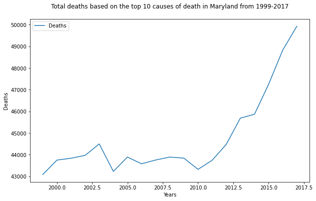

```python
#Creating a dataframe of the total causes of death from 1999-2017 in Maryland
all_causes_MD = data_MD.copy()
for i, row in all_causes_MD.iterrows():
    if row["Cause Name"] != "All causes":
        all_causes_MD.drop(i, inplace=True)
#Unfortunately the row for 2007 is out of order so we need to reorder the dataframe
all_causes_MD = all_causes_MD.sort_values('Year')
print(all_causes_MD)
all_causes_MD.plot(x="Year", y="Deaths", figsize=(10,6))
plt.xlabel("Years")
plt.ylabel("Deaths")
plt.title("Total deaths based on the top 10 causes of death in Maryland from 1999-2017\n")
plt.show()
```

```
       Year  Cause Name     State  Deaths
10374  1999  All causes  Missouri   55931
9803   2000  All causes  Missouri   54865
9230   2001  All causes  Missouri   54982
8658   2002  All causes  Missouri   55940
8085   2003  All causes  Missouri   55582
7514   2004  All causes  Missouri   53950
6941   2005  All causes  Missouri   54656
6369   2006  All causes  Missouri   54681
4619   2007  All causes  Missouri   54166
5248   2008  All causes  Missouri   56578
4670   2009  All causes  Missouri   54263
4086   2010  All causes  Missouri   55281
3514   2011  All causes  Missouri   55848
2941   2012  All causes  Missouri   56094
2367   2013  All causes  Missouri   57444
1795   2014  All causes  Missouri   58320
1222   2015  All causes  Missouri   59871
650    2016  All causes  Missouri   59873
78     2017  All causes  Missouri   61876
```

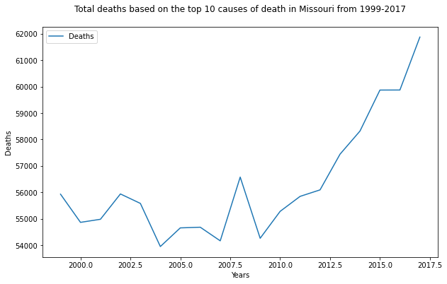

```python
#Creating a dataframe of the total causes of death from 1999-2017 in Missouri
all_causes_MO = data_MO.copy()
for i, row in all_causes_MO.iterrows():
    if row["Cause Name"] != "All causes":
        all_causes_MO.drop(i, inplace=True)
#Unfortunately the row for 2007 is out of order so we need to reorder the dataframe
all_causes_MO = all_causes_MO.sort_values('Year')
print(all_causes_MO)
all_causes_MO.plot(x="Year", y="Deaths", figsize=(10,6))
plt.xlabel("Years")
plt.ylabel("Deaths")
plt.title("Total deaths based on the top 10 causes of death in Missouri from 1999-2017\n")
plt.show()
```

Based on these 3 graphs, you can clearly see that they all have a very similar shape. Starting from 1999 to around 2009 you can see a balanced relationship in regards to the deaths fluctuating but always staying near the total death count since 1999. After 2009, you see a near rapid exponential growth rate for the total death count from around 2010 to 2017. This applies to all 3 graphs, they all follow a similar path all throughout the years.

A question you may be wondering is why all of a sudden is there this huge exponential growth from 2010 to 2017. Well, we can take a look at what exactly is the difference between 2010 and 2017 in the United States:

```
      Year               Cause Name          State   Deaths
4313  2010                 Diabetes  United States    69071
4576  2010           Kidney disease  United States    50476
4470  2010                  Suicide  United States    38364
4417  2010  Influenza and pneumonia  United States    50097
4365  2010            Heart disease  United States   597689
4522  2010                   Cancer  United States   574743
4261  2010                     CLRD  United States   138080
4157  2010      Alzheimer's disease  United States    83494
4105  2010               All causes  United States  2468435
4053  2010   Unintentional injuries  United States   120859
4209  2010                   Stroke  United States   129476
```

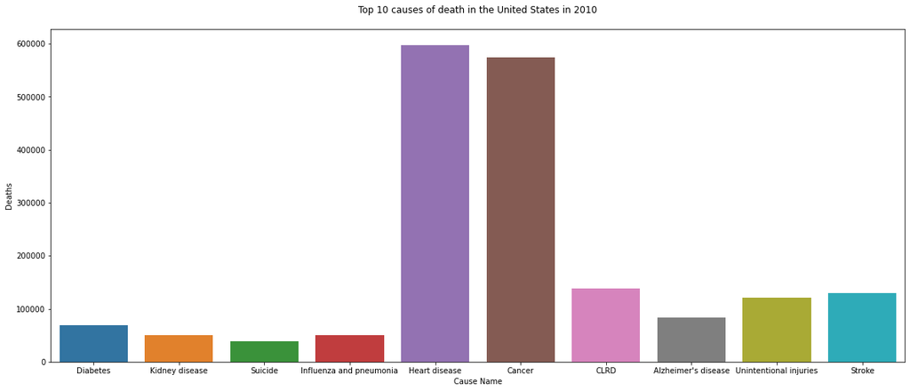

```python
#For United States dataframe: Removing unnecessary rows/years and the "all causes" cause name for the columns.
data_US_temp = data_US[data_US["Year"] == 2010]
print(data_US_temp)
#Dropping "All causes" at this index
data_US_temp.drop(4105, axis=0, inplace=True)
#Only focusing in 2010
plt.figure(figsize=(20,8))
plt.xlabel("Cause Name")
plt.ylabel("Deaths")
plt.title("Top 10 causes of death in the United States in 2010\n")
sns.barplot(data=data_US_temp, x="Cause Name", y="Deaths")
plt.show()
```

```
     Year               Cause Name          State   Deaths
0    2017   Unintentional injuries  United States   169936
260  2017                 Diabetes  United States    83564
521  2017           Kidney disease  United States    50633
469  2017                   Cancer  United States   599108
416  2017                  Suicide  United States    47173
312  2017            Heart disease  United States   647457
364  2017  Influenza and pneumonia  United States    55672
208  2017                     CLRD  United States   160201
156  2017                   Stroke  United States   146383
104  2017      Alzheimer's disease  United States   121404
52   2017               All causes  United States  2813503
```

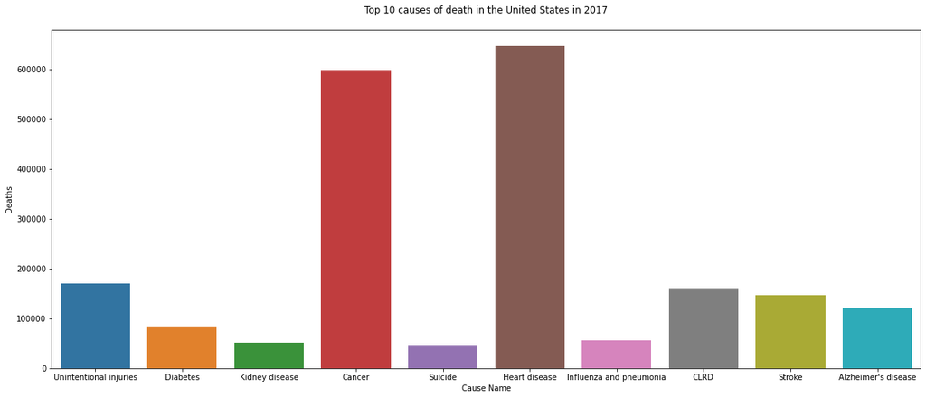

```python
#For United States dataframe: Removing unnecessary rows/years and the "all causes" cause name for the columns.
data_US_temp = data_US[data_US["Year"] == 2017]
print(data_US_temp)
#Dropping "All causes" at this index
data_US_temp.drop(52, axis=0, inplace=True)
#Only focusing in 2017
plt.figure(figsize=(20,8))
plt.xlabel("Cause Name")
plt.ylabel("Deaths")
plt.title("Top 10 causes of death in the United States in 2017\n")
sns.barplot(data=data_US_temp, x="Cause Name", y="Deaths")
plt.show()
```

```python
print(all_causes_US[all_causes_US["Year"] == 2010])
print(all_causes_US[all_causes_US["Year"] == 2017])
```

```
      Year  Cause Name          State   Deaths
4105  2010  All causes  United States  2468435
    Year  Cause Name          State   Deaths
52  2017  All causes  United States  2813503
```

```
     Year               Cause Name     State  Deaths
21   2017   Unintentional injuries  Maryland    2408
281  2017                 Diabetes  Maryland    1439
542  2017           Kidney disease  Maryland     830
490  2017                   Cancer  Maryland   10796
437  2017                  Suicide  Maryland     630
333  2017            Heart disease  Maryland   11653
385  2017  Influenza and pneumonia  Maryland     990
229  2017                     CLRD  Maryland    2079
177  2017                   Stroke  Maryland    2820
125  2017      Alzheimer's disease  Maryland    1191
73   2017               All causes  Maryland   49926
```

[figure not shown]

```python
#For Maryland dataframe: Removing unnecessary rows/years and the "all causes" cause name for the columns.
data_MD_temp = data_MD[data_MD["Year"] == 2017]
print(data_MD_temp)
#Dropping "All causes" at this index
data_MD_temp.drop(73, axis=0, inplace=True)
#Only focusing in 2017
plt.figure(figsize=(20,8))
plt.xlabel("Cause Name")
plt.ylabel("Deaths")
plt.title("Top 10 causes of death in Maryland in 2017\n")
sns.barplot(data=data_US_temp, x="Cause Name", y="Deaths")
plt.show()
```

```
     Year               Cause Name     State  Deaths
26   2017   Unintentional injuries  Missouri    3776
286  2017                 Diabetes  Missouri    1605
547  2017           Kidney disease  Missouri    1515
495  2017                   Cancer  Missouri   12971
442  2017                  Suicide  Missouri    1151
338  2017            Heart disease  Missouri   14820
390  2017  Influenza and pneumonia  Missouri    1281
234  2017                     CLRD  Missouri    3940
182  2017                   Stroke  Missouri    3159
130  2017      Alzheimer's disease  Missouri    2545
78   2017               All causes  Missouri   61876
```

[figure not shown]

```python
#For Missouri dataframe: Removing unnecessary rows/years and the "all causes" cause name for the columns.
data_MO_temp = data_MO[data_MO["Year"] == 2017]
print(data_MO_temp)
#Dropping "All causes" at this index
data_MO_temp.drop(78, axis=0, inplace=True)
#Only focusing in 2017
plt.figure(figsize=(20,8))
plt.xlabel("Cause Name")
plt.ylabel("Deaths")
plt.title("Top 10 causes of death in Missouri in 2017\n")
sns.barplot(data=data_US_temp, x="Cause Name", y="Deaths")
plt.show()
```

```python
print(all_causes_MD[all_causes_MD["Year"] == 2017])
print(all_causes_MO[all_causes_MO["Year"] == 2017])
```

```
    Year  Cause Name     State  Deaths
73  2017  All causes  Maryland   49926
    Year  Cause Name     State  Deaths
78  2017  All causes  Missouri   61876
```